# Cyclistic Data Analysis Project - Full Report

Hazem El-Mancy

2022-04-02

## Overview

This report is a part of the [“Google Data Analytics Professional Certificate’s”](https://www.coursera.org/professional-certificates/google-data-analytics) capstone project offered by [Coursera](https://www.coursera.org/). In this report, the chosen case study is the first problem in track#1, also known as ‘Cyclistic,’ an imaginary bike-sharing company in Chicago. The company offers both traditional and assistive bikes to both casual riders and riders who are annual members.

## Scenario

“You are a junior data analyst working in the marketing analyst team at Cyclistic, a bike share company in Chicago. The director of marketing believes the company’s future success depends on maximizing the number of annual memberships. Therefore, your team wants to understand how casual riders and annual members use Cyclistic bikes differently. From these insights, your team will design a new marketing strategy to convert casual riders into annual members. But first, Cyclistic executives must approve your recommendations, so they must be backed up with compelling data insights and professional data visualizations”.

## Business Task

The questions that the stakeholders want answer in this scenario are:

- How do annual members and casual riders use Cyclistic bikes differently?
- Why would casual riders buy Cyclistic annual memberships?
- How can Cyclistic use digital media to influence casual riders to become members?

From these questions, the priority-1 task in this project is to identify the differences of bike usage between annual members and casual riders. Then, use those differences to figure out how to keep the existing and attract new annual members to maximize Cyclistic’s profit.

## Project Scripts

- R code [here](https://github.com/HazemMancy/Bike-Share-Capstone/blob/main/BikeShare.r)
- RMarkdown code [here](https://github.com/HazemMancy/Bike-Share-Capstone/blob/main/Cyclistic%20Data%20Analysis%20Project%20-%20Full%20Report.rmd)

## Data Preparation

Data used is the last 12 months data of ride trips made by casual and member riders. The links to data are below:

- [March-2021](https://divvy-tripdata.s3.amazonaws.com/202103-divvy-tripdata.zip)
- [April-2021](https://divvy-tripdata.s3.amazonaws.com/202104-divvy-tripdata.zip)
- [May-2021](https://divvy-tripdata.s3.amazonaws.com/202105-divvy-tripdata.zip)
- [June-2021](https://divvy-tripdata.s3.amazonaws.com/202106-divvy-tripdata.zip)
- [July-2021](https://divvy-tripdata.s3.amazonaws.com/202107-divvy-tripdata.zip)
- [August-2021](https://divvy-tripdata.s3.amazonaws.com/202108-divvy-tripdata.zip)
- [September-2021](https://divvy-tripdata.s3.amazonaws.com/202109-divvy-tripdata.zip)
- [October-2021](https://divvy-tripdata.s3.amazonaws.com/202110-divvy-tripdata.zip)
- [November-2021](https://divvy-tripdata.s3.amazonaws.com/202111-divvy-tripdata.zip)
- [December-2021](https://divvy-tripdata.s3.amazonaws.com/202112-divvy-tripdata.zip)
- [January-2022](https://divvy-tripdata.s3.amazonaws.com/202201-divvy-tripdata.zip)
- [February-2022](https://divvy-tripdata.s3.amazonaws.com/202202-divvy-tripdata.zip)

Now, we can open RStudio and create new script and start data analysis journey.

### Load libraries

```r
library(tidyverse)
```

```r
library(readr)
library(tidyr)
library(dplyr)
library(stringr)
library(ggplot2)
library(lubridate)
library(janitor)
library(skimr)
```

### Import Data

```r
Mar_2021 <-
  read.csv(
    "C:/Users/hazem/Desktop/Case-Studies/Bike-Share/data/202103-divvy-tripdata.csv"
  )
Apr_2021 <-
  read.csv(
    "C:/Users/hazem/Desktop/Case-Studies/Bike-Share/data/202104-divvy-tripdata.csv"
  )
May_2021 <-
  read.csv(
    "C:/Users/hazem/Desktop/Case-Studies/Bike-Share/data/202105-divvy-tripdata.csv"
  )
Jun_2021 <-
  read.csv(
    "C:/Users/hazem/Desktop/Case-Studies/Bike-Share/data/202106-divvy-tripdata.csv"
  )
Jul_2021 <-
  read.csv(
    "C:/Users/hazem/Desktop/Case-Studies/Bike-Share/data/202107-divvy-tripdata.csv"
  )
Aug_2021 <-
  read.csv(
    "C:/Users/hazem/Desktop/Case-Studies/Bike-Share/data/202108-divvy-tripdata.csv"
  )
Sep_2021 <-
  read.csv(
    "C:/Users/hazem/Desktop/Case-Studies/Bike-Share/data/202109-divvy-tripdata.csv"
  )
Oct_2021 <-
  read.csv(
    "C:/Users/hazem/Desktop/Case-Studies/Bike-Share/data/202110-divvy-tripdata.csv"
  )
Nov_2021 <-
  read.csv(
    "C:/Users/hazem/Desktop/Case-Studies/Bike-Share/data/202111-divvy-tripdata.csv"
  )
Dec_2021 <-
  read.csv(
    "C:/Users/hazem/Desktop/Case-Studies/Bike-Share/data/202112-divvy-tripdata.csv"
  )
Jan_2022 <-
  read.csv(
    "C:/Users/hazem/Desktop/Case-Studies/Bike-Share/data/202201-divvy-tripdata.csv"
  )
Feb_2022 <-
  read.csv(
    "C:/Users/hazem/Desktop/Case-Studies/Bike-Share/data/202202-divvy-tripdata.csv"
  )
```

## Data Processing

First, let’s have a look on what we have.

```r
glimpse(Mar_2021)
```

```
## Rows: 228,496
## Columns: 13
## $ ride_id            <chr> "CFA86D4455AA1030", "30D9DC61227D1AF3", "846D87A156~
## $ rideable_type      <chr> "classic_bike", "classic_bike", "classic_bike", "cl~
## $ started_at         <chr> "2021-03-16 08:32:30", "2021-03-28 01:26:28", "2021~
## $ ended_at           <chr> "2021-03-16 08:36:34", "2021-03-28 01:36:55", "2021~
## $ start_station_name <chr> "Humboldt Blvd & Armitage Ave", "Humboldt Blvd & Ar~
## $ start_station_id   <chr> "15651", "15651", "15443", "TA1308000021", "525", "~
## $ end_station_name   <chr> "Stave St & Armitage Ave", "Central Park Ave & Bloo~
## $ end_station_id     <chr> "13266", "18017", "TA1308000043", "13323", "E008", ~
## $ start_lat          <dbl> 41.91751, 41.91751, 41.84273, 41.96881, 42.01270, 4~
## $ start_lng          <dbl> -87.70181, -87.70181, -87.63549, -87.65766, -87.666~
## $ end_lat            <dbl> 41.91774, 41.91417, 41.83066, 41.95283, 42.05049, 4~
## $ end_lng            <dbl> -87.69139, -87.71676, -87.64717, -87.64999, -87.677~
## $ member_casual      <chr> "casual", "casual", "casual", "casual", "casual", "~
```

Since we are going to bind all months data in one data frame, it is important that all data frames columns have the same name and datatype. So, we can use the code below to compare them first.

```r
compare_df_cols(
  Mar_2021,
  Apr_2021,
  May_2021,
  Jun_2021,
  Jul_2021,
  Aug_2021,
  Sep_2021,
  Oct_2021,
  Nov_2021,
  Dec_2021,
  Jan_2022,
  Feb_2022,
  return = "mismatch"
)
```

```
##  [1] column_name Mar_2021    Apr_2021    May_2021    Jun_2021    Jul_2021
##  [7] Aug_2021    Sep_2021    Oct_2021    Nov_2021    Dec_2021    Jan_2022
## [13] Feb_2022
## <0 rows> (or 0-length row.names)
```

We can follow the following steps to make columns specs identical and check again if there is mismatch before binding.

All datatypes are perfect except start and end datetime. Let’s convert them to date.

```r
Mar_2021 <-
  mutate(Mar_2021,
         started_at = as_datetime(started_at),
         ended_at = as_datetime(ended_at))

Apr_2021 <-
  mutate(Apr_2021,
         started_at = as_datetime(started_at),
         ended_at = as_datetime(ended_at))

May_2021 <-
  mutate(May_2021,
         started_at = as_datetime(started_at),
         ended_at = as_datetime(ended_at))

Jun_2021 <-
  mutate(Jun_2021,
         started_at = as_datetime(started_at),
         ended_at = as_datetime(ended_at))

Jul_2021 <-
  mutate(Jul_2021,
         started_at = as_datetime(started_at),
         ended_at = as_datetime(ended_at))

Aug_2021 <-
  mutate(Aug_2021,
         started_at = as_datetime(started_at),
         ended_at = as_datetime(ended_at))

Sep_2021 <-
  mutate(Sep_2021,
         started_at = as_datetime(started_at),
         ended_at = as_datetime(ended_at))

Oct_2021 <-
  mutate(Oct_2021,
         started_at = as_datetime(started_at),
         ended_at = as_datetime(ended_at))

Nov_2021 <-
  mutate(Nov_2021,
         started_at = as_datetime(started_at),
         ended_at = as_datetime(ended_at))

Dec_2021 <-
  mutate(Dec_2021,
         started_at = as_datetime(started_at),
         ended_at = as_datetime(ended_at))

Jan_2022 <-
  mutate(Jan_2022,
         started_at = as_datetime(started_at),
         ended_at = as_datetime(ended_at))

Feb_2022 <-
  mutate(Feb_2022,
         started_at = as_datetime(started_at),
         ended_at = as_datetime(ended_at))
```

Check if there any duplicates to be removed

```r
Mar_2021[duplicated(Mar_2021)]
```

```
## data frame with 0 columns and 228496 rows
```

```r
Apr_2021[duplicated(Apr_2021)]
```

```
## data frame with 0 columns and 337230 rows
```

```r
May_2021[duplicated(May_2021)]
```

```
## data frame with 0 columns and 531633 rows
```

```r
Jun_2021[duplicated(Jun_2021)]
```

```
## data frame with 0 columns and 729595 rows
```

```r
Jul_2021[duplicated(Jul_2021)]
```

```
## data frame with 0 columns and 822410 rows
```

```r
Aug_2021[duplicated(Aug_2021)]
```

```
## data frame with 0 columns and 804352 rows
```

```r
Sep_2021[duplicated(Sep_2021)]
```

```
## data frame with 0 columns and 756147 rows
```

```r
Oct_2021[duplicated(Oct_2021)]
```

```
## data frame with 0 columns and 631226 rows
```

```r
Nov_2021[duplicated(Nov_2021)]
```

```
## data frame with 0 columns and 359978 rows
```

```r
Dec_2021[duplicated(Dec_2021)]
```

```
## data frame with 0 columns and 247540 rows
```

```r
Jan_2022[duplicated(Jan_2022)]
```

```
## data frame with 0 columns and 103770 rows
```

```r
Feb_2022[duplicated(Feb_2022)]
```

```
## data frame with 0 columns and 115609 rows
```

There are no duplicates. Now compare data frames again and bind them into one data frame.

```r
compare_df_cols(
  Mar_2021,
  Apr_2021,
  May_2021,
  Jun_2021,
  Jul_2021,
  Aug_2021,
  Sep_2021,
  Oct_2021,
  Nov_2021,
  Dec_2021,
  Jan_2022,
  Feb_2022,
  return = "mismatch"
)
```

```
##  [1] column_name Mar_2021    Apr_2021    May_2021    Jun_2021    Jul_2021
##  [7] Aug_2021    Sep_2021    Oct_2021    Nov_2021    Dec_2021    Jan_2022
## [13] Feb_2022
## <0 rows> (or 0-length row.names)
```

Now, we can bind all data frames together into one data frame.

```r
last_12_months_trips <- bind_rows(
  Mar_2021,
  Apr_2021,
  May_2021,
  Jun_2021,
  Jul_2021,
  Aug_2021,
  Sep_2021,
  Oct_2021,
  Nov_2021,
  Dec_2021,
  Jan_2022,
  Feb_2022
)
head(last_12_months_trips)
```

```
##            ride_id rideable_type          started_at            ended_at
## 1 CFA86D4455AA1030  classic_bike 2021-03-16 08:32:30 2021-03-16 08:36:34
## 2 30D9DC61227D1AF3  classic_bike 2021-03-28 01:26:28 2021-03-28 01:36:55
## 3 846D87A15682A284  classic_bike 2021-03-11 21:17:29 2021-03-11 21:33:53
## 4 994D05AA75A168F2  classic_bike 2021-03-11 13:26:42 2021-03-11 13:55:41
## 5 DF7464FBE92D8308  classic_bike 2021-03-21 09:09:37 2021-03-21 09:27:33
## 6 CEBA8516FD17F8D8  classic_bike 2021-03-20 11:08:47 2021-03-20 11:29:39
##             start_station_name start_station_id
## 1 Humboldt Blvd & Armitage Ave            15651
## 2 Humboldt Blvd & Armitage Ave            15651
## 3        Shields Ave & 28th Pl            15443
## 4  Winthrop Ave & Lawrence Ave     TA1308000021
## 5     Glenwood Ave & Touhy Ave              525
## 6     Glenwood Ave & Touhy Ave              525
##                      end_station_name end_station_id start_lat start_lng
## 1             Stave St & Armitage Ave          13266  41.91751 -87.70181
## 2 Central Park Ave & Bloomingdale Ave          18017  41.91751 -87.70181
## 3                Halsted St & 35th St   TA1308000043  41.84273 -87.63549
## 4              Broadway & Sheridan Rd          13323  41.96881 -87.65766
## 5           Chicago Ave & Sheridan Rd           E008  42.01270 -87.66606
## 6           Chicago Ave & Sheridan Rd           E008  42.01270 -87.66606
##    end_lat   end_lng member_casual
## 1 41.91774 -87.69139        casual
## 2 41.91417 -87.71676        casual
## 3 41.83066 -87.64717        casual
## 4 41.95283 -87.64999        casual
## 5 42.05049 -87.67782        casual
## 6 42.05049 -87.67782        casual
```

Since rideable_type and member_casual are categorical, we can transform them to factors.

```r
last_12_months_trips <- last_12_months_trips %>%
  mutate(rideable_type = as.factor(rideable_type)) %>%
  mutate(member_casual = as.factor(member_casual))
```

We have to create new columns that will help us to answer questions. These columns will give us information about each trip month, day of the week, hour of day, and time duration.

```r
last_12_months_trips$day_of_week <-
  format(as.Date(last_12_months_trips$started_at), "%A")

last_12_months_trips$month <-
  format(as.Date(last_12_months_trips$started_at), "%b")

last_12_months_trips$hour_of_day <-
  format(last_12_months_trips$started_at, format = "%H")

last_12_months_trips$ride_duration <-
  difftime(last_12_months_trips$ended_at,
           last_12_months_trips$started_at)
```

Convert ride duration to numeric to be shown as seconds.

```r
last_12_months_trips <-
  mutate(last_12_months_trips, ride_duration = as.numeric(ride_duration))
```

Check if there are ride duration < 0

```r
count(last_12_months_trips, ride_duration < 0)
```

```
##   ride_duration < 0       n
## 1             FALSE 5667841
## 2              TRUE     145
```

Exclude illogical ride duration

```r
last_12_months_trips <-
  filter(last_12_months_trips, ride_duration >= 0)
```

Convert ride duration from seconds to minutes

```r
last_12_months_trips <-
  mutate(last_12_months_trips, ride_duration = (ride_duration / 60))
```

Now, we can use `last_12_months_trips` data frame and start analysis and answer questions.

## Data Analysis & Visualization

First, we can use summary function and try to get thoughts about data

```r
summary(last_12_months_trips)
```

```
##    ride_id                rideable_type       started_at
##  Length:5667841     classic_bike :3268713   Min.   :2021-03-01 00:01:09
##  Class :character   docked_bike  : 311283   1st Qu.:2021-06-13 11:41:27
##  Mode  :character   electric_bike:2087845   Median :2021-08-07 19:11:51
##                                             Mean   :2021-08-10 07:32:40
##                                             3rd Qu.:2021-10-02 14:15:39
##                                             Max.   :2022-02-28 23:58:44
##
##     ended_at                   start_station_name start_station_id
##  Min.   :2021-03-01 00:06:28   Length:5667841     Length:5667841
##  1st Qu.:2021-06-13 12:08:45   Class :character   Class :character
##  Median :2021-08-07 19:34:17   Mode  :character   Mode  :character
##  Mean   :2021-08-10 07:54:25
##  3rd Qu.:2021-10-02 14:38:40
##  Max.   :2022-03-01 08:55:17
##
##  end_station_name   end_station_id       start_lat       start_lng
##  Length:5667841     Length:5667841     Min.   :41.64   Min.   :-87.84
##  Class :character   Class :character   1st Qu.:41.88   1st Qu.:-87.66
##  Mode  :character   Mode  :character   Median :41.90   Median :-87.64
##                                        Mean   :41.90   Mean   :-87.65
##                                        3rd Qu.:41.93   3rd Qu.:-87.63
##                                        Max.   :45.64   Max.   :-73.80
##
##     end_lat         end_lng       member_casual    day_of_week
##  Min.   :41.39   Min.   :-88.97   casual:2540634   Length:5667841
##  1st Qu.:41.88   1st Qu.:-87.66   member:3127207   Class :character
##  Median :41.90   Median :-87.64                    Mode  :character
##  Mean   :41.90   Mean   :-87.65
##  3rd Qu.:41.93   3rd Qu.:-87.63
##  Max.   :42.17   Max.   :-87.49
##  NA's   :4617    NA's   :4617
##     month           hour_of_day        ride_duration
##  Length:5667841     Length:5667841     Min.   :    0.00
##  Class :character   Class :character   1st Qu.:    6.67
##  Mode  :character   Mode  :character   Median :   11.87
##                                        Mean   :   21.75
##                                        3rd Qu.:   21.57
##                                        Max.   :55944.15
##
```

Number of trips per month:

```r
trips_per_month <- last_12_months_trips %>%
  group_by(month) %>%
  summarise(number_of_rides = n()) %>%
  arrange(desc(number_of_rides))
trips_per_month
```

```
## # A tibble: 12 x 2
##    month number_of_rides
##    <chr>           <int>
##  1 Jul            822397
##  2 Aug            804323
##  3 Sep            756111
##  4 Jun            729590
##  5 Oct            631226
##  6 May            531631
##  7 Nov            359925
##  8 Apr            337225
##  9 Dec            247540
## 10 Mar            228494
## 11 Feb            115609
## 12 Jan            103770
```

### How do annual members and casual riders use Cyclistic bikes differently?

- According to month of the year:

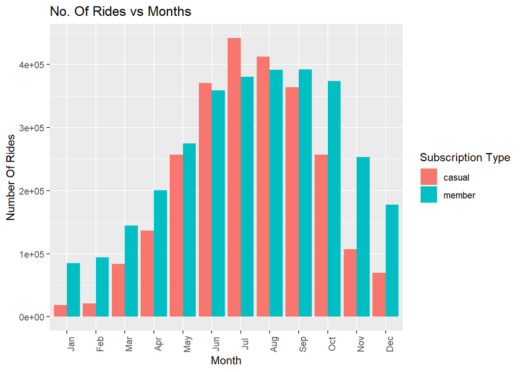

```r
ggplot(data = last_12_months_trips,
       mapping = aes(x = month, fill = member_casual)) +
  geom_bar(position = "dodge") +
  labs(title = "No. Of Rides vs Months",
       x = "Month",
       y = "Number Of Rides",
       fill = "Subscription Type") +
  theme(axis.text.x = element_text(angle = 90)) +
  scale_x_discrete(
    limits = c(
      "Jan",
      "Feb",
      "Mar",
      "Apr",
      "May",
      "Jun",
      "Jul",
      "Aug",
      "Sep",
      "Oct",
      "Nov",
      "Dec"
    )
  )
```

It seems that number of trips is high goes up during summer. During summer months (June, July, and August), casual rides exceeds member rides.

- According to day of the weeks:

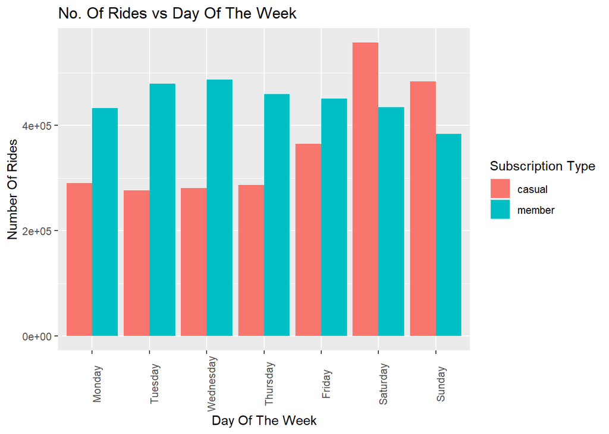

```r
ggplot(data = last_12_months_trips,
       mapping = aes(x = day_of_week, fill = member_casual)) +
  geom_bar(position = "dodge") +
  labs(title = "No. Of Rides vs Day Of The Week",
       x = "Day Of The Week",
       y = "Number Of Rides",
       fill = "Subscription Type") +
  theme(axis.text.x = element_text(angle = 90)) +
  scale_x_discrete(
    limits = c(
      "Monday",
      "Tuesday",
      "Wednesday",
      "Thursday",
      "Friday",
      "Saturday",
      "Sunday"
    )
  )
```

Member rides almost the same all days of the week. Unlikely, casual rides rise up and even more than member rides during weekends. This confirms that Cyclistic users are more likely to ride for leisure.

- According hour of the day:

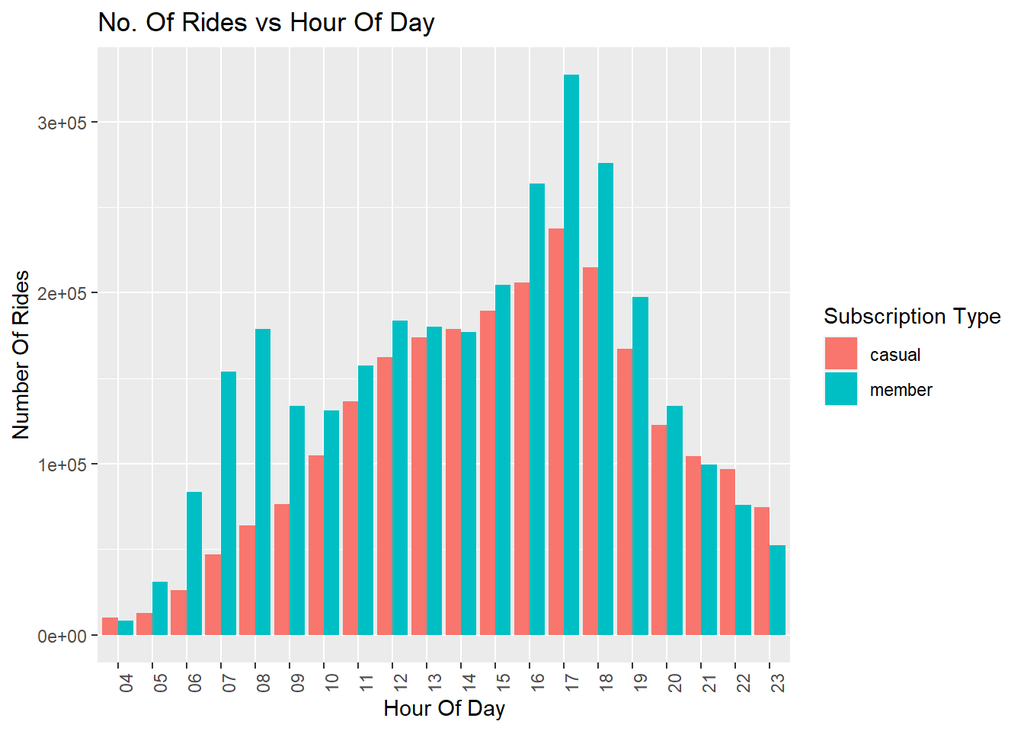

```r
ggplot(data = last_12_months_trips,
       mapping = aes(x = hour_of_day, fill = member_casual)) +
  geom_bar(position = "dodge") +
  labs(title = "No. Of Rides vs Hour Of Day",
       x = "Hour Of Day",
       y = "Number Of Rides",
       fill = "Subscription Type") +
  theme(axis.text.x = element_text(angle = 90)) +
  scale_x_discrete(
    limits = c(
      "04",
      "05",
      "06",
      "07",
      "08",
      "09",
      "10",
      "11",
      "12",
      "13",
      "14",
      "15",
      "16",
      "17",
      "18",
      "19",
      "20",
      "21",
      "22",
      "23"
    )
  )
```

Member rides are high during rush hours which confirms the fact that about 30% of users use bikes to commute to work each day.

- According to bike type:

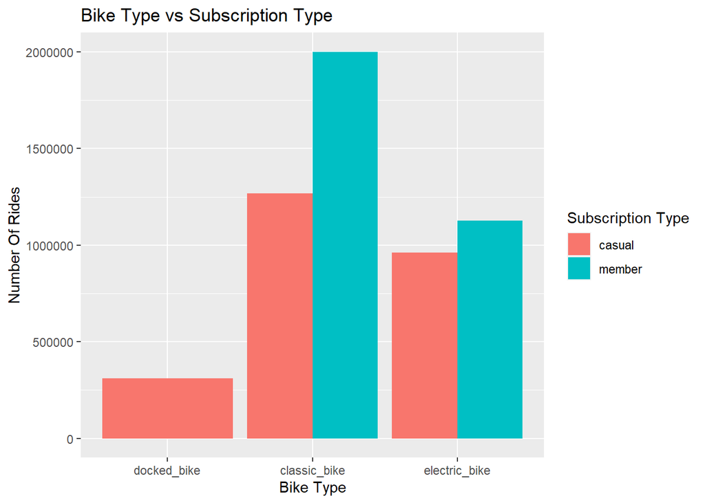

```r
ggplot(data = last_12_months_trips,
       mapping = aes(x = rideable_type, fill = member_casual)) +
  geom_bar(position = "dodge") +
  labs(title = "Bike Type vs Subscription Type",
       x = "Bike Type",
       y = "Number Of Rides",
       fill = "Subscription Type") +
  scale_x_discrete(limits = c("docked_bike",
                              "classic_bike",
                              "electric_bike"))
```

Classic bike is the most popular bike for both casual and member riders. Members do not use docked bike.

### Casual Rides vs Member Rides:

```r
summary(last_12_months_trips$member_casual)
```

```
##  casual  member
## 2540634 3127207
```

Percentage in piechart:

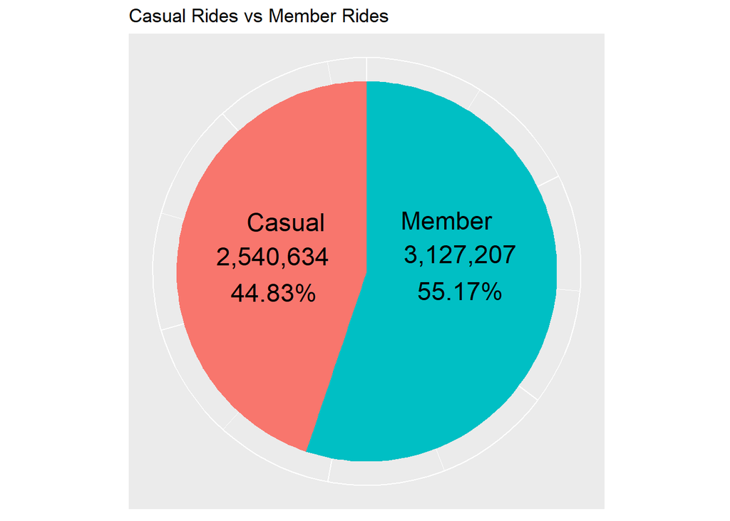

```r
piechart <- data.frame(
  subscription_type = c("casual", "member"),
  value = summary(last_12_months_trips$member_casual)
)

ggplot(data = piechart,
       mapping = aes(x = "", y = value, fill = subscription_type)) +
  geom_bar(stat = "identity", width = 1) +
  coord_polar("y", start = 0) +
  labs(title = "Casual Rides vs Member Rides")+
  theme(
    axis.ticks = element_blank(),
    axis.text = element_blank(),
    axis.title = element_blank(),
    legend.position = "none"
  ) +
  annotate(
    "text",
    label = "Member",
    x = 1,
    y = 900000,
    size = 6
  ) +
  annotate(
    "text",
    label = "3,127,207",
    x = 1,
    y = 1250000,
    size = 6
  ) +
  annotate(
    "text",
    label = "55.17%",
    x = 1,
    y = 1600000,
    size = 6
  ) +
  annotate(
    "text",
    label = "Casual",
    x = 1,
    y = 4750000,
    size = 6
  ) +
  annotate(
    "text",
    label = "2,540,634",
    x = 1,
    y = 4400000,
    size = 6
  ) +
  annotate(
    "text",
    label = "44.83%",
    x = 1,
    y = 4050000,
    size = 6
  )
```

Member rides are more than casual rides.

### Top high number of rides start stations:

```r
start_stations <- last_12_months_trips %>%
  filter(!start_station_name == "") %>%
  group_by(start_station_name) %>%
  summarise(number_of_rides = n()) %>%
  arrange(desc(number_of_rides))

head(start_stations, n = 10)
```

```
## # A tibble: 10 x 2
##    start_station_name       number_of_rides
##    <chr>                              <int>
##  1 Streeter Dr & Grand Ave            82953
##  2 Michigan Ave & Oak St              44408
##  3 Wells St & Concord Ln              43968
##  4 Millennium Park                    42399
##  5 Clark St & Elm St                  41315
##  6 Wells St & Elm St                  37895
##  7 Theater on the Lake                36768
##  8 Kingsbury St & Kinzie St           34616
##  9 Clark St & Lincoln Ave             33346
## 10 Wabash Ave & Grand Ave             33214
```

These top stations are highly recommended to start the marketting plan.

## Recommendations:

In last sections we answered the first question of the business task and explained how annual members and casual riders use Cyclistic bikes differently. In this sectition we are going to use insights to give recommendations that could answer the last two questions. Top recommendations are listed below.

- Since casual riders tend to rent Cyclistic bikes during summer months, we can make a marketing plan with offers and discounts to target them before and during these months.
- We don’t have enough information to know if the increase in number of rides in summer is because of tourists that visit Chicago in these months. If we have home city addresses of riders, we can use them to decide if we can new branches in these cities. As they likes our bikes, by these new branches, we can convince them to be annual members.
- Marketing plan should start with stations of top rides.

[output not shown]

- Since the aim is to convert casual riders to annual members, we can set up a new price list with flexible prices plan to convince casual riders to be annual members.